# Seoul Bike Sharing Demand Analysis

**Group 2: Xiao Hu, Vinky Wang, Izzy Zhang**

## Introduction

The bike-sharing system has made public transportation cleaner and more convenient as citizens can get access to bicycles across the city. As of 2020, 3200 bikes were being offered in Seoul, South Korea [1]. However, imbalance in demand and bicycles supplied can create problems for both users and system operators. Predicting bicycle usage helps guide companies to control the amount of bikes to deploy. In our project, we will be using different environmental variables and time as predictors for the hourly count of bike rentals.

The dataset was collected by the website of “South Korea Public Holidays” [2] and used by Sathishkumar et al. to test different data mining techniques and to make inferences and predictions [1].

## Preliminary Results

### Reading the Data

We will first read in the `SeoulBikeData.csv` and load packages that we will use for the analyses.

```r
# Load data
url = "https://archive.ics.uci.edu/ml/machine-learning-databases/00560/SeoulBikeData.csv"
bike = read.csv(url,check.names=F)
```

```r
# Load packages
library(tidyverse)
library(lubridate)
library(corrplot)
library(car)
library(repr)
```

### Data Pre-Processing

Now we will do some data cleaning and wrangling to get our data into a tidy format.

```r
# Rename columns
colnames(bike) <- c("date", "count", "hour", "temp", "humidity", "windspeed", "visibility", "dew", "solar", "rain", "snow", "seasons", "holiday", "functioning")
```

```r
# Convert variable into different classes
bike <- bike %>%
  mutate(date = as.POSIXct(date, format = "%d/%m/%Y"), # date
         month =  factor(months(date)),      # add months variable
         seasons = factor(seasons), # factor
         holiday = factor(holiday), # factor
         functioning = factor(functioning)) # factor
```

```r
# Peak of our data
glimpse(bike)
```

```
Rows: 8,760
Columns: 15
$ date        <dttm> 2017-12-01, 2017-12-01, 2017-12-01, 2017-12-01, 2017-12-0…
$ count       <int> 254, 204, 173, 107, 78, 100, 181, 460, 930, 490, 339, 360,…
$ hour        <int> 0, 1, 2, 3, 4, 5, 6, 7, 8, 9, 10, 11, 12, 13, 14, 15, 16, …
$ temp        <dbl> -5.2, -5.5, -6.0, -6.2, -6.0, -6.4, -6.6, -7.4, -7.6, -6.5…
$ humidity    <int> 37, 38, 39, 40, 36, 37, 35, 38, 37, 27, 24, 21, 23, 25, 26…
$ windspeed   <dbl> 2.2, 0.8, 1.0, 0.9, 2.3, 1.5, 1.3, 0.9, 1.1, 0.5, 1.2, 1.3…
$ visibility  <int> 2000, 2000, 2000, 2000, 2000, 2000, 2000, 2000, 2000, 1928…
$ dew         <dbl> -17.6, -17.6, -17.7, -17.6, -18.6, -18.7, -19.5, -19.3, -1…
$ solar       <dbl> 0.00, 0.00, 0.00, 0.00, 0.00, 0.00, 0.00, 0.00, 0.01, 0.23…
$ rain        <dbl> 0, 0, 0, 0, 0, 0, 0, 0, 0, 0, 0, 0, 0, 0, 0, 0, 0, 0, 0, 0…
$ snow        <dbl> 0, 0, 0, 0, 0, 0, 0, 0, 0, 0, 0, 0, 0, 0, 0, 0, 0, 0, 0, 0…
$ seasons     <fct> Winter, Winter, Winter, Winter, Winter, Winter, Winter, Wi…
$ holiday     <fct> No Holiday, No Holiday, No Holiday, No Holiday, No Holiday…
$ functioning <fct> Yes, Yes, Yes, Yes, Yes, Yes, Yes, Yes, Yes, Yes, Yes, Yes…
$ month       <fct> December, December, December, December, December, December…
```

```r
head(bike, 10)
```

A data.frame: 10 × 15

|  | date <dttm> | count <int> | hour <int> | temp <dbl> | humidity <int> | windspeed <dbl> | visibility <int> | dew <dbl> | solar <dbl> | rain <dbl> | snow <dbl> | seasons <fct> | holiday <fct> | functioning <fct> | month <fct> |
| --- | --- | --- | --- | --- | --- | --- | --- | --- | --- | --- | --- | --- | --- | --- | --- |
| 1 | 2017-12-01 | 254 | 0 | -5.2 | 37 | 2.2 | 2000 | -17.6 | 0.00 | 0 | 0 | Winter | No Holiday | Yes | December |
| 2 | 2017-12-01 | 204 | 1 | -5.5 | 38 | 0.8 | 2000 | -17.6 | 0.00 | 0 | 0 | Winter | No Holiday | Yes | December |
| 3 | 2017-12-01 | 173 | 2 | -6.0 | 39 | 1.0 | 2000 | -17.7 | 0.00 | 0 | 0 | Winter | No Holiday | Yes | December |
| 4 | 2017-12-01 | 107 | 3 | -6.2 | 40 | 0.9 | 2000 | -17.6 | 0.00 | 0 | 0 | Winter | No Holiday | Yes | December |
| 5 | 2017-12-01 | 78 | 4 | -6.0 | 36 | 2.3 | 2000 | -18.6 | 0.00 | 0 | 0 | Winter | No Holiday | Yes | December |
| 6 | 2017-12-01 | 100 | 5 | -6.4 | 37 | 1.5 | 2000 | -18.7 | 0.00 | 0 | 0 | Winter | No Holiday | Yes | December |
| 7 | 2017-12-01 | 181 | 6 | -6.6 | 35 | 1.3 | 2000 | -19.5 | 0.00 | 0 | 0 | Winter | No Holiday | Yes | December |
| 8 | 2017-12-01 | 460 | 7 | -7.4 | 38 | 0.9 | 2000 | -19.3 | 0.00 | 0 | 0 | Winter | No Holiday | Yes | December |
| 9 | 2017-12-01 | 930 | 8 | -7.6 | 37 | 1.1 | 2000 | -19.8 | 0.01 | 0 | 0 | Winter | No Holiday | Yes | December |
| 10 | 2017-12-01 | 490 | 9 | -6.5 | 27 | 0.5 | 1928 | -22.4 | 0.23 | 0 | 0 | Winter | No Holiday | Yes | December |

```r
summary(bike)
```

```
      date                         count             hour
 Min.   :2017-12-01 00:00:00   Min.   :   0.0   Min.   : 0.00
 1st Qu.:2018-03-02 00:00:00   1st Qu.: 191.0   1st Qu.: 5.75
 Median :2018-06-01 00:00:00   Median : 504.5   Median :11.50
 Mean   :2018-06-01 00:20:52   Mean   : 704.6   Mean   :11.50
 3rd Qu.:2018-08-31 00:00:00   3rd Qu.:1065.2   3rd Qu.:17.25
 Max.   :2018-11-30 00:00:00   Max.   :3556.0   Max.   :23.00

      temp           humidity       windspeed       visibility
 Min.   :-17.80   Min.   : 0.00   Min.   :0.000   Min.   :  27
 1st Qu.:  3.50   1st Qu.:42.00   1st Qu.:0.900   1st Qu.: 940
 Median : 13.70   Median :57.00   Median :1.500   Median :1698
 Mean   : 12.88   Mean   :58.23   Mean   :1.725   Mean   :1437
 3rd Qu.: 22.50   3rd Qu.:74.00   3rd Qu.:2.300   3rd Qu.:2000
 Max.   : 39.40   Max.   :98.00   Max.   :7.400   Max.   :2000

      dew              solar             rain              snow
 Min.   :-30.600   Min.   :0.0000   Min.   : 0.0000   Min.   :0.00000
 1st Qu.: -4.700   1st Qu.:0.0000   1st Qu.: 0.0000   1st Qu.:0.00000
 Median :  5.100   Median :0.0100   Median : 0.0000   Median :0.00000
 Mean   :  4.074   Mean   :0.5691   Mean   : 0.1487   Mean   :0.07507
 3rd Qu.: 14.800   3rd Qu.:0.9300   3rd Qu.: 0.0000   3rd Qu.:0.00000
 Max.   : 27.200   Max.   :3.5200   Max.   :35.0000   Max.   :8.80000

   seasons           holiday     functioning      month
 Autumn:2184   Holiday   : 432   No : 295    August  : 744
 Spring:2208   No Holiday:8328   Yes:8465    December: 744
 Summer:2208                                 January : 744
 Winter:2160                                 July    : 744
                                             March   : 744
                                             May     : 744
                                             (Other) :4296
```

### Exploratory Data Analysis

We will conduct an exploratory data analysis to explore questions mentioned in the introduction and get a better sense of our data.

Let's first look at the overall distribution of bike rentals across time.

[figure not shown]

```r
# Plot of all time counts
options(repr.plot.width = 18, repr.plot.height = 9)

bike %>%
  ggplot(aes(x=date, y = count)) +
  geom_col() +
  scale_x_datetime(breaks = "1 month") +
  ylab("Count") +
  xlab("Time") +
  theme_minimal() +
  theme(legend.position = "none")
```

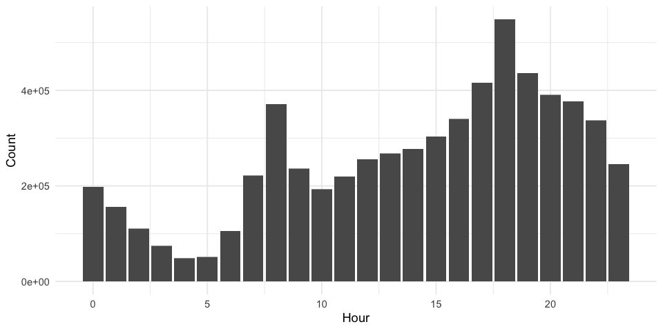

```r
# Plot of hourly counts
options(repr.plot.width = 8, repr.plot.height = 4)

bike %>%
  ggplot(aes(hour, count)) +
  geom_col() +
  ylab("Count") +
  xlab("Hour") +
  theme_minimal() +
  theme(legend.position = "none")
```

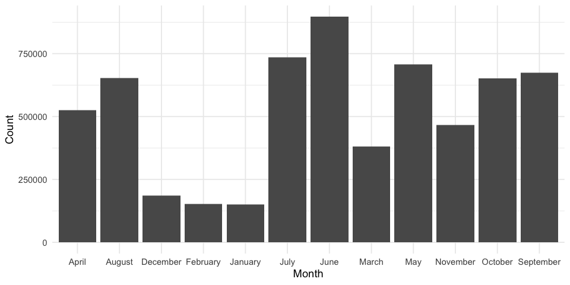

```r
# Plot monthly counts
optbions(repr.plot.width = 8, repr.plot.height = 4)

bike %>%
  ggplot(aes(month, count)) +
  geom_col() +
  ylab("Count") +
  xlab("Month") +
  theme_minimal() +
  theme(legend.position = "none")
```

It appears that the most number of rentals of all time was during the summer months of 2018. The most popular hour for rentals is around 6pm. The most popular month for rentals is in June.

### Multi-collinearity

Now we will identify variables that are correlated with one another and select a subset of the dataset that minimizes multicollinearity.

```r
# Select only numeric environmental variables
bike_var <- bike %>%
  select(c(temp, humidity, windspeed, visibility, dew, solar, rain, snow))
```

```r
# Correlation matrix
cor_matrix <- cor(bike_var)
cor_matrix
```

A matrix: 8 × 8 of type dbl

|  | temp | humidity | windspeed | visibility | dew | solar | rain | snow |
| --- | --- | --- | --- | --- | --- | --- | --- | --- |
| temp | 1.00000000 | 0.1593708 | -0.036251701 | 0.03479443 | 0.91279822 | 0.35350547 | 0.050281859 | -0.218404862 |
| humidity | 0.15937080 | 1.0000000 | -0.336683042 | -0.54309034 | 0.53689449 | -0.46191880 | 0.236396670 | 0.108183453 |
| windspeed | -0.03625170 | -0.3366830 | 1.000000000 | 0.17150714 | -0.17648569 | 0.33227425 | -0.019674089 | -0.003554186 |
| visibility | 0.03479443 | -0.5430903 | 0.171507137 | 1.00000000 | -0.17662973 | 0.14973803 | -0.167629238 | -0.121694515 |
| dew | 0.91279822 | 0.5368945 | -0.176485692 | -0.17662973 | 1.00000000 | 0.09438135 | 0.125596737 | -0.150886707 |
| solar | 0.35350547 | -0.4619188 | 0.332274246 | 0.14973803 | 0.09438135 | 1.00000000 | -0.074290110 | -0.072300823 |
| rain | 0.05028186 | 0.2363967 | -0.019674089 | -0.16762924 | 0.12559674 | -0.07429011 | 1.000000000 | 0.008499653 |
| snow | -0.21840486 | 0.1081835 | -0.003554186 | -0.12169451 | -0.15088671 | -0.07230082 | 0.008499653 | 1.000000000 |

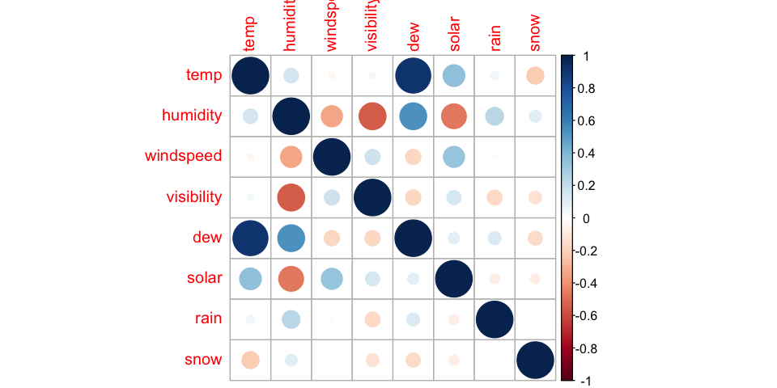

```r
# Correlation plot
corrplot(cor_matrix, use = "complete.obs", method="circle")
```

```r
# Variance inflation factor selection (<5)
## all variables
model_vif1 <- lm(count~ temp + humidity + windspeed + visibility + dew + solar + rain + snow, data = bike)
vif(model_vif1)
```

**temp**

86.6451763908546

**humidity**

20.3227686586929

**windspeed**

1.20230491294036

**visibility**

1.55552352007477

**dew**

115.474241781173

**solar**

1.98194518442869

**rain**

1.08166370156728

**snow**

1.09288186151354

```r
## remove dew variable
model_vif2 <- lm(count~ temp + humidity + windspeed + visibility  + solar + rain + snow, data = bike)
vif(model_vif2)
```

**temp**

1.54350824824929

**humidity**

2.38827083405998

**windspeed**

1.19907324809169

**visibility**

1.54410441385075

**solar**

1.89072677955679

**rain**

1.06718013250489

**snow**

1.08758574342473

## Methods: Plan

Since our response variable is the number of rented bikes per hour, we will build a Poisson regression model to predict the demand for rental bikes in Seoul. The model can be written as:

$$\log (E[Y|X]) = \beta_0 + \beta_1 X_1 + \beta_2 X_2 + ... + \beta_p X_p$$

where $Y \sim Pois(\mu)$ and $E[Y|X] = \mu$.

We will split the dataset into training data and test data. The training data will be used to select and fit the predictive model. Because Lasso regularization can reduce the model complexicity and prevent overfitting, we will use Lasso regularization to obtain the optimal subsets of input variables and evaluate the goodness of fit of the model by deviance and likelihood ratio test. After variable selection, we will use the trained model to predict the response of the test set and evaluate the prediction accuracy by root-mean-square error.

In the final report, We expect to see a significant association between the number of rented bikes and explanatory variables. We aim to obtain a precise prediction of rental demand from our regularized Poisson regression model. Our model could be used to predict the demand for rental bikes in Seoul on both working days and holidays under different weather conditions. This report could be helpful for bicycle rentals to provide a stable supply and for the government or urban planners to manage public bicycle traffic.

## References

[1] Sathishkumar V E, Jangwoo Park, and Yongyun Cho. 'Using data mining techniques for bike sharing demand prediction in metropolitan city.' Computer Communications, Vol.153, pp.353-366, March, 2020

[2] SOUTH KOREA PUBLIC HOLIDAYS. URL: publicholidays.go.kr

[3] O’brien, R. M. (2007). A caution regarding rules of thumb for variance inflation factors. Quality & Quantity, 41(5), 673–690. https://doi.org/10.1007/s11135-006-9018-6

[4] Wickham, H. (2014). Tidy Data. Journal of Statistical Software, 59(10). https://doi.org/10.18637/jss.v059.i10